# The options of *fclust*

Benoît Jaillard

2020-11-30

The function *fclust* can work using different methods and models managed by options. The three main options are **opt.method**, **opt.model** and **opt.mean**. Additional option is **opt.jack**. The options are defined by default for focusing on the main results provided by a functional clustering. They are: *opt.tree = list(“prd”, “leg”), opt.perf = list(“prd”, “pub”), opt.motif = list(“obs”, “hor”, “leg”)*.

## The option *opt.method*

**opt.method** determines the method of clustering. The option can be **“divisive”**, **“agglomerative”** or **“apriori”**. All methods generate hierarchical trees. Each tree is complete, running from a unique trunk to as many leaves as components.

- If **opt.method = “divisive”**, the components are clustered from the trivial cluster where all components are together, towards the clustering where each component is isolated in a cluster. This method is very efficient because the first component partioning change considerably the coefficient of determination of clustering model. The first divisions are thus very discriminative, and it is therefore possible to surely observe the effect on performance of co-occurring components within assemblages.
- If **opt.method = “agglomerative”**, the components are clustered from the trivial clustering where each component is isolated in a cluster, towards the cluster where all components are together. In most cases, the first component clustering do not change the coefficient of determination of clustering model: the first clustering are not discriminative and it is therefore not possible to select the component combinations associated with the strongest effects of assemblage performance.

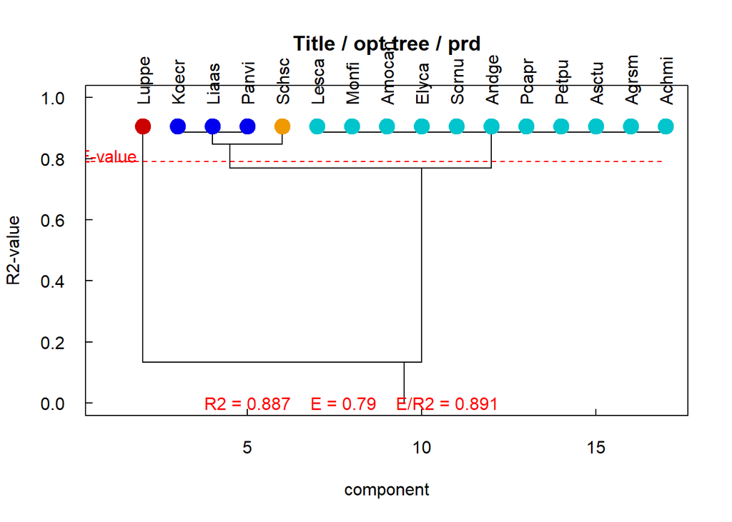

```r
res <- fclust(dat.2004, nbElt, opt.method = "divisive")
fclust_plot(res, opt.tree = list("prd"))

res <- fclust(dat.2004, nbElt, opt.method = "agglomerative")
fclust_plot(res, opt.tree = list("prd"))
```

[output not shown]

- **opt.method = “apriori”** : the option assumes that the user knows an *a priori* partitioning of the system components he is studying. The partition is arbitrary, in any number of clusters of components, as long as it is complete, *i.e.* it includes as many components as the system includes. In this option, an *a priori* component partition, noted **affectElt**, should be provided. **affectElt** is a vector of *integers* or *characters* of length *nbElt*. A hierarchical tree is then built, by using *opt.method = “divisive”* from the *a priori* defined component partition towards the uppermost part of tree (towards tree leaves), and by using *opt.method = “agglomerative”* from the *a priori* defined component partition towards the lowest part of tree (towards tree trunk). The resulting tree is therefore forced by the given, *a priori* component partition *affectElt*.  
  Note that *opt.method = “apriori”* with *affectElt = rep(1, nbElt)* is equivalent to *opt.method = “divisive”*, since the *a priori* partitioning consists of a single cluster that brings together all the components of the system. In contrary, *opt.method = “apriori”* with *affectElt = seq_len(nbElt)* is equivalent to *opt.method = “agglomerative”*, since the *a priori* partitioning consists of isolating each component in a cluster.

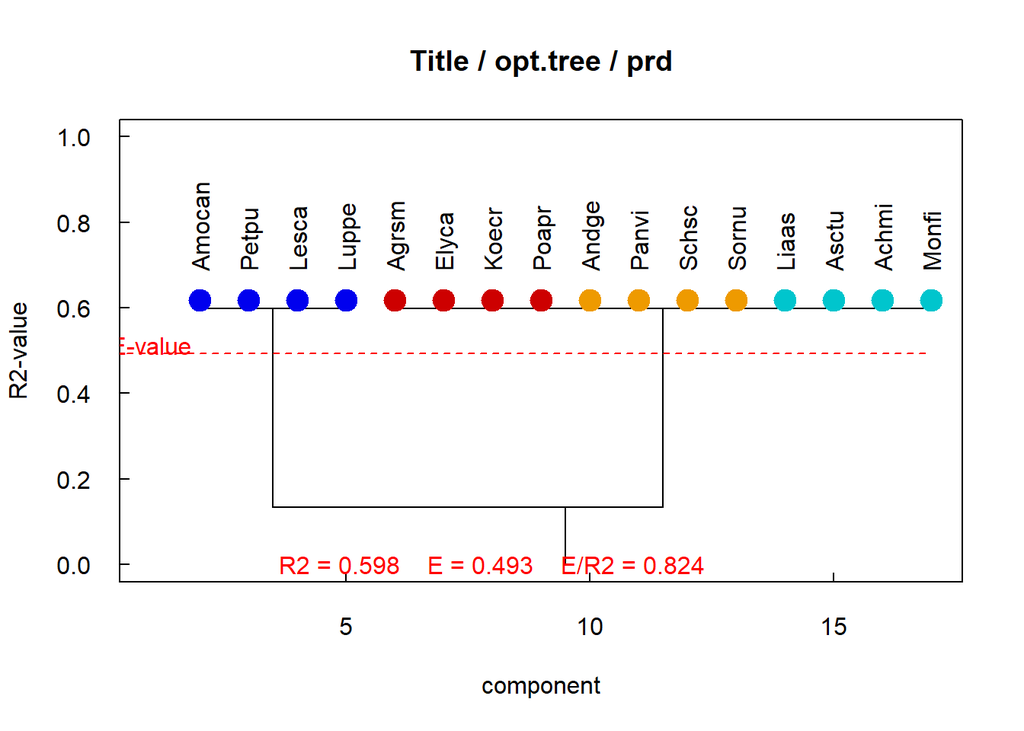

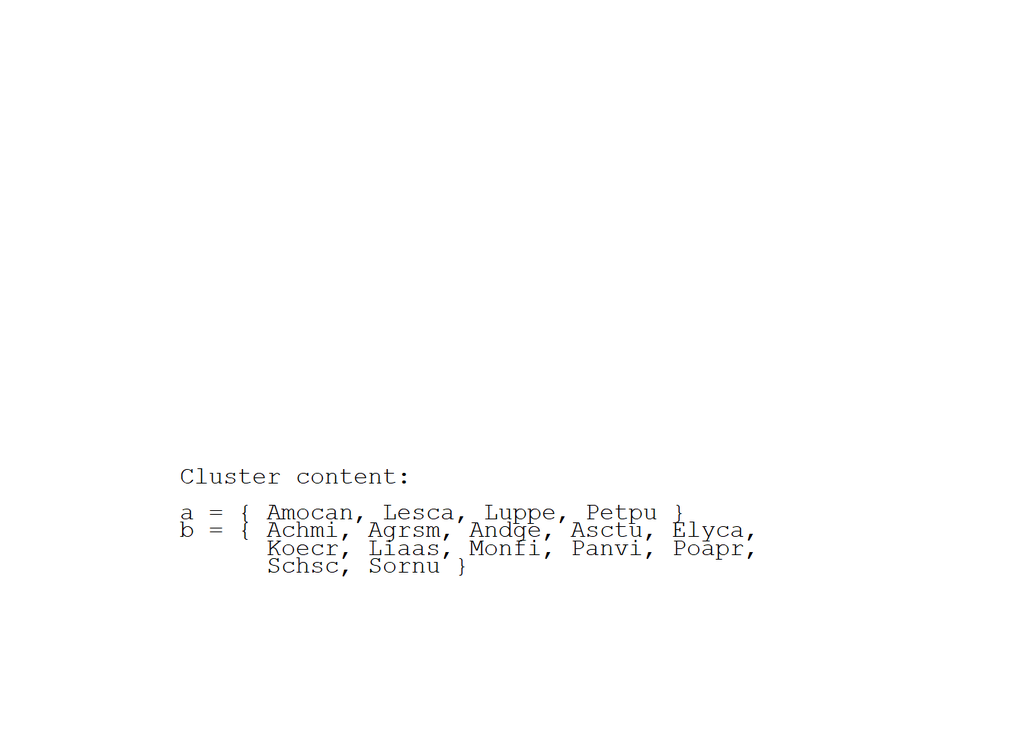

Opt.method=‘apriori’ forces the hierarchical tree to include a given component partition

```r
apriori <- c(1,3,2,4,1,3,3,2,1,2,1,4,2,3,4,4)
apriori <- c("F","C3","L","C4","F","C3","C3","L","F","L","F","C4","L","C3","C4","C4")

res <- fclust(dat.2004, nbElt, opt.method = "apriori", affectElt = apriori)
fclust_plot(res, opt.tree = list("prd", "leg", cols = apriori))
```

## The option *opt.model*

**opt.model** determines the model for predicting assemblage performance. The option can be **“bymot”** or **“byelt”**.

- **opt.mod = “bymot”**: the option is the simplest one. The performances are modelled as the mean performance of assemblages that share a same assembly motif, by including all assemblages that belong to the same assembly motif. Consequently, all assemblages that share a same assembly motif have the same predicted performance, whatever their component composition. The modelling of assemblage performances is therefore based only on the partitioning of components into functional groups, and the resulting partitioning of assemblages into assembly motifs. It does not take into account the fact that the elementary composition of each assemblage differs from one assemblage to another within the same assembly motif, and that these elementary compositions are known.
- **opt.model = “byelt”**: the option uses the fact that the elementary composition of each assemblage differs from one assemblage to another within the same assembly motif, and that these elementary compositions are known. Within each assembly motif, the performances of assemblages that contain a given components are first averaged. Consequently, a mean value of performance is associated with each component that occurs within the assembly motif. Second the performance of each assemblage is computed as the mean of mean performances of assemblages that contain the same components as the assemblage to predict. If no assemblage contains component belonging to assemblage to predict, performance is computed as the mean performance of all assemblages that share a same assembly motif, as in *opt.mod = “bymot”*. As a whole, this procedure partitions assemblages by assembly motif and adds a linear model within each assembly motif based on the component occurrence within each assemblage. This procedure can improve the explanatory and predictive abilities of the modelling (see Jaillard *et al*., 2018a, Meth. Ecol. Evol.).

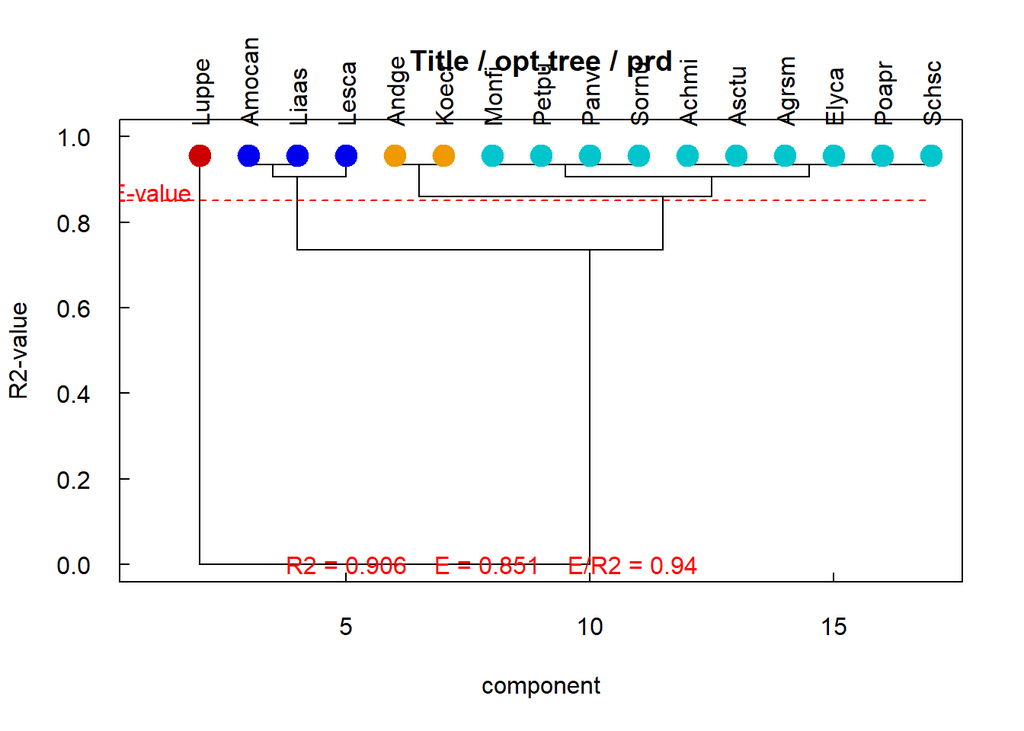

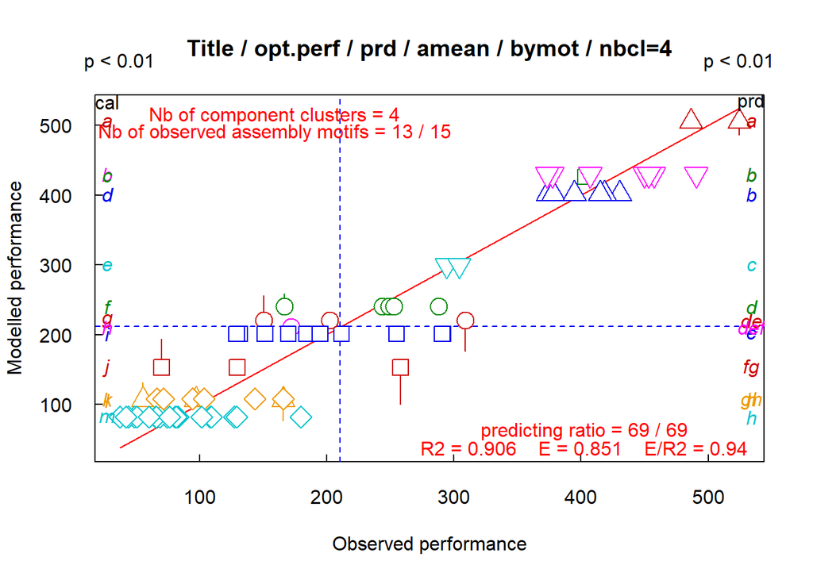

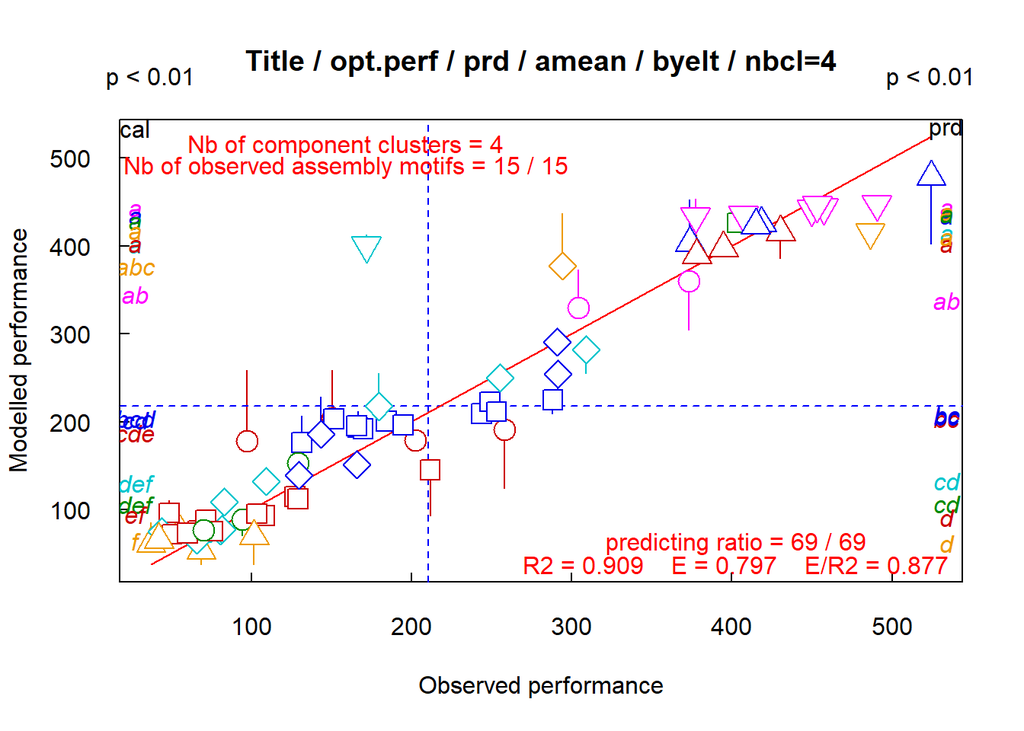

Opt.model determines the model for predicting assemblage performance

```r
res <- fclust(dat.2004, nbElt, opt.mod = "bymot")
fclust_plot(res, opt.tree = list("prd"), opt.perf = list("prd", "aov", pvalue = 0.01))

res <- fclust(dat.2004, nbElt, opt.mod = "byelt")
fclust_plot(res, opt.tree = list("prd"), opt.perf = list("prd", "aov", pvalue = 0.01))
```

[output not shown]

Both the highest graphs correspond to *opt.model = “bymot”*, both the lowest graphs to *opt.model = “byelt”*. The resulting trees are different: the first *red*group contains *Luppe* in both the trees, the second *blue*-group contains *Liaas* and *Lesca* in both the trees, but differs by *Amocan* and *Koecr*, the third *gold“*group contains* Andge* in both the trees, but *Koecr* in *bymot*-tree and several other species in *byelt*-tree, etc…. The coefficients of determination are equivalent (*R2* = 0.906 against 0.909), and the predictive ability of assemblage performances are more robust with *opt.model = “bymot”* than with *opt.model = “byelt”* (*E* = 0.851 against 0.797, then *E/R2* = 0.940 against 0.877). However, our experiment suggests that *opt.model = “byelt”* gives the most likely result.

## The option *opt.mean*

**opt.mean** determines the formula to use in averaging. The option can be **“amean”** or **“gmean”**. Functional clustering is based on computations of mean performances of assemblages, differently partitioned. The mean formula to use depends on the distribution of assemblage performance: it can shift a little the resuls.

- If **opt.mean = “amean”**, mean performances are computed using an arithmetic formula.
- If **opt.mean = “gmean”**, mean performances are computed using a geometric formula.

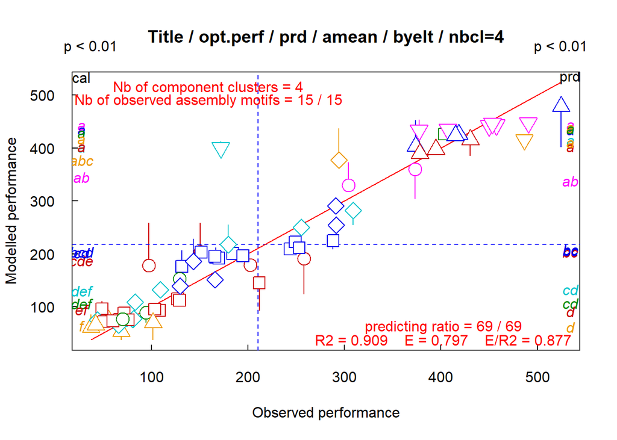

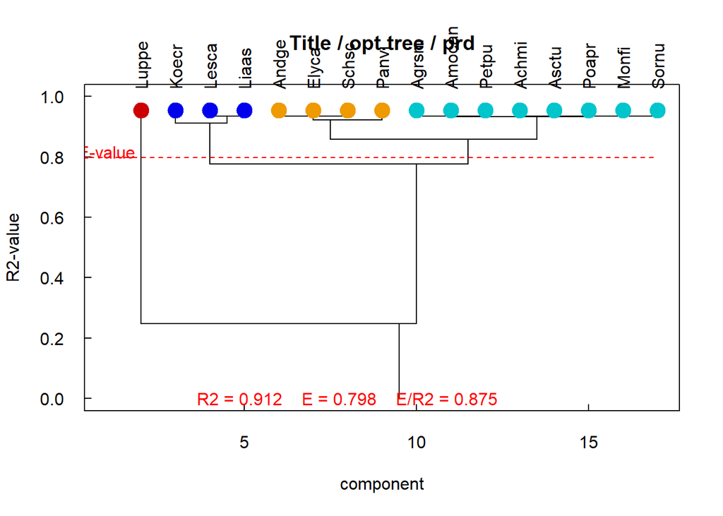

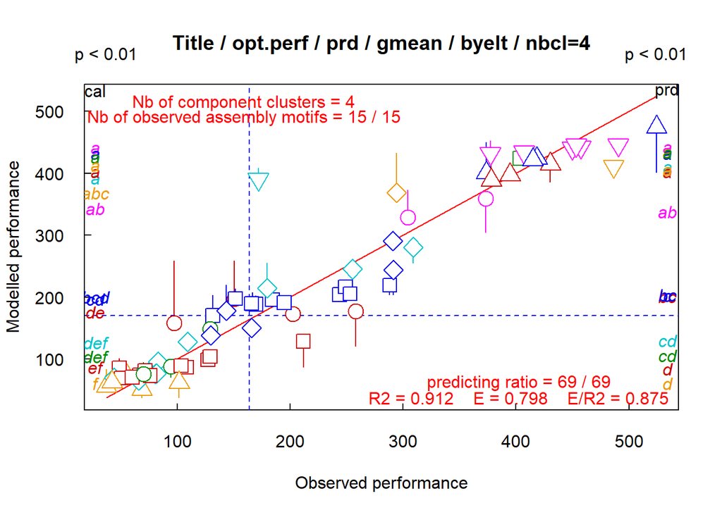

Opt.mean determines the formula to use in averaging

```r
res <- fclust(dat.2004, nbElt, opt.mean = "amean")
fclust_plot(res, opt.tree = list("prd"), opt.perf = list("prd", "aov", pvalue = 0.01))

res <- fclust(dat.2004, nbElt, opt.mean = "gmean")
fclust_plot(res, opt.tree = list("prd"), opt.perf = list("prd", "aov", pvalue = 0.01))
```

[output not shown]

## The option *opt.jack*

**opt.jack** determines the method of cross-validation. By default (*opt.jack = FALSE*), the performance of each assemblage is predicted by a Leave-One-Out method: the performance of each assemblage is predicted as the mean performance of assemblages that share a same assembly motif, except the only assemblage to predict. If the number of assemblages that share a same assembly motif is large, Leave-One-Out method is time-consuming. It is more convenient to switch towards a jackknife method (*opt.jack = TRUE*): the performances of assemblages that belong to each subset are predicted as the mean performance of assemblages of other subsets, except the assemblage subset to predict. **jack** then specifies how to divide the assemblage collection. *jack* is an integer vector of length *2*: the first integer specifies the size of subset, the second integer specifies the number of subsets.

## Note

Note that some computations are time-consuming. To facilitate the monitoring of the smooth running of the computations, informations are written on the Console and graphs are drawn on the Plots panel. The writting are activated or deactivated by the “verbose” option.

```r
getOption("verbose")
```

```
#> [1] FALSE
```

```r
# to follow the computations
options(verbose = TRUE)
# to deactivate the option
options(verbose = FALSE)
```